# 4.ts_regression

Bongus

2019 5 8

# 시계열 회귀분석

## 시계열 회귀분석: 시계열분석과 회귀분석이 같이 이루어지는 모델

### 시계열 & 회귀분석

1. 설명변수를 가지고 목적변수와 관계를 모델화 => 미래의 목적변수를 예측가능.
2. 데이터에 설명변수(Customer, Open, Promotion, Holiday)가 포함, 설명변수들을 이용해 회귀분석을 수행.
3. 회귀분석을 위해 lm() 함수를 사용.
4. 미래예측 위해선 미래의 x값을 알아야 한다. 하지만 미래값을 예측하기는 쉽지 않음.
5. 시계열 회귀분석은 시계열 모형과 회귀모형을 같이 사용하는 것인데, 회귀분석을 이용하기 위해 미래 x변수(들의 정보가 필요하다. 회귀분석을 위해 미래 x데이터에 대한 예측도 같이 진행되어야 한다.

```r
library(forecast)
library(tseries)

# data
sales_data <- read.csv('./data/ts_reg_s1.csv')
head(sales_data)
```

```
##   Store       Date Sales Customers Open Promo SchoolHoliday
## 1     1 2013-08-01  4994       555    1     1             1
## 2     1 2013-08-02  4494       562    1     1             1
## 3     1 2013-08-03  4461       553    1     0             1
## 4     1 2013-08-04     0         0    0     0             1
## 5     1 2013-08-05  4086       522    1     0             1
## 6     1 2013-08-06  3582       477    1     0             1
```

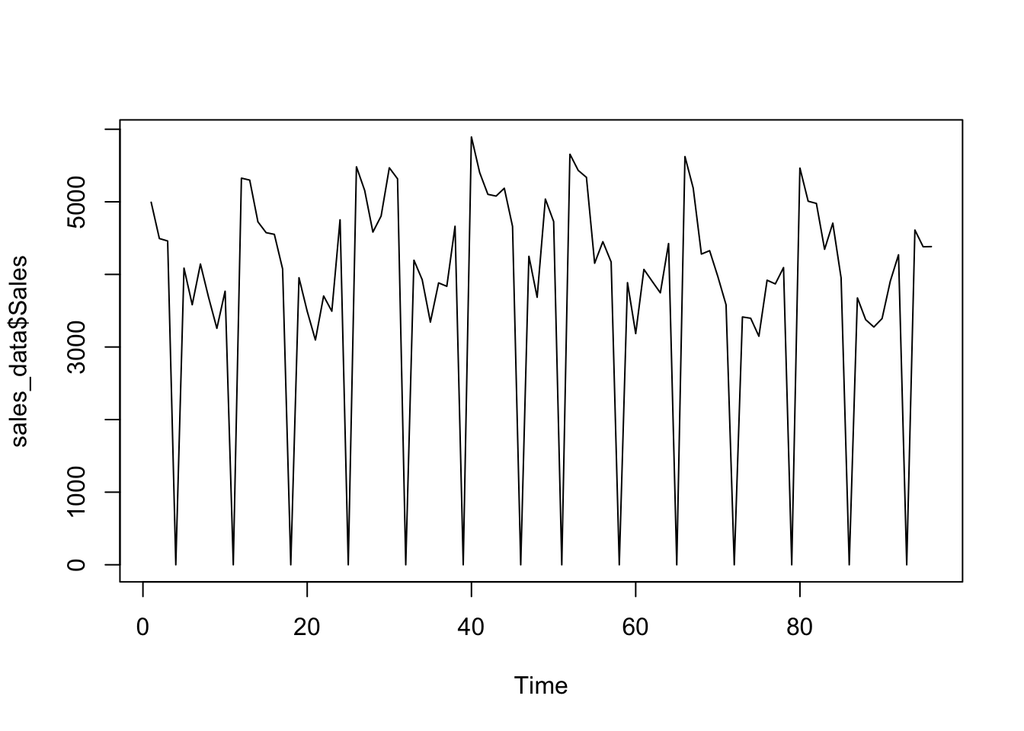

```r
ts.plot(sales_data$Sales)
```

```r
# train, test
sales_train <- sales_data[1:89,]
test <- sales_data[90:96,]

# lm
sales_lm <- lm(Sales ~ Open+Promo+SchoolHoliday, data= sales_train)
summary(sales_lm)
```

```
##
## Call:
## lm(formula = Sales ~ Open + Promo + SchoolHoliday, data = sales_train)
##
## Residuals:
##    Min     1Q Median     3Q    Max
## -951.6 -285.7   16.7  278.3 1346.3
##
## Coefficients:
##               Estimate Std. Error t value Pr(>|t|)
## (Intercept)      88.12     134.64   0.654   0.5146
## Open           3882.56     141.48  27.443   <2e-16 ***
## Promo          1115.62     105.00  10.625   <2e-16 ***
## SchoolHoliday  -163.65      97.65  -1.676   0.0975 .
## ---
## Signif. codes:  0 '***' 0.001 '**' 0.01 '*' 0.05 '.' 0.1 ' ' 1
##
## Residual standard error: 446.9 on 85 degrees of freedom
## Multiple R-squared:  0.9322, Adjusted R-squared:  0.9298
## F-statistic: 389.5 on 3 and 85 DF,  p-value: < 2.2e-16
```

6. 계수, 잔차 p-value 순서.
7. 잔차분석(Durbin-Watson Test): 설명이 안된 부분은 잔차에 남아있다. 나머지 잔차가 어떤 모형인지가 회귀분석 성능을 보는 척도. 잔차가 백색소음인지 테스트한다.
- Durbin-Watson Test: lmset packages => dwtest
8. 잔차에 자기상관이 있는지 확인, 자기상관이 있으면 다시 시계열 분석을 할 수 있다. 잔차를 ARIMA모형으로 한번 더 분석한다. 남은 잔차가 백색소음이 되도록 만든다.
9. 정리: 시계열회귀분석은 선형회귀모형으로 1차 모델링 한 후, 남으 잔차를 시계열모형(ARIMA)으로 한번 더 모델링하여 최종모형을 만든다. 실제 알고리즘은 회귀분석 -> ARIMA분석으로 계산하지않고 파라미터들을 한꺼번에 계산한다.

```r
# Regression with TS
library(forecast)
library(tseries)

# data
sales_data <- read.csv('./data/ts_reg_s1.csv')
head(sales_data)
```

```
##   Store       Date Sales Customers Open Promo SchoolHoliday
## 1     1 2013-08-01  4994       555    1     1             1
## 2     1 2013-08-02  4494       562    1     1             1
## 3     1 2013-08-03  4461       553    1     0             1
## 4     1 2013-08-04     0         0    0     0             1
## 5     1 2013-08-05  4086       522    1     0             1
## 6     1 2013-08-06  3582       477    1     0             1
```

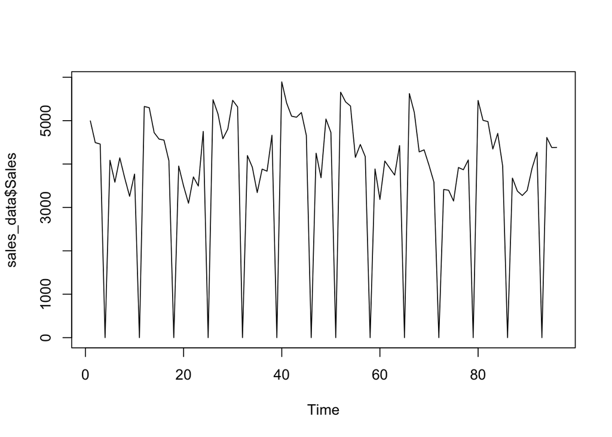

```r
ts.plot(sales_data$Sales)
```

```r
# train, test
sales_train <- sales_data[1:89,]
sales_test <- sales_data[90:96,]

# lm
sales_lm <- lm(Sales ~ Open+Promo+SchoolHoliday, data= sales_train)
summary(sales_lm)
```

```
##
## Call:
## lm(formula = Sales ~ Open + Promo + SchoolHoliday, data = sales_train)
##
## Residuals:
##    Min     1Q Median     3Q    Max
## -951.6 -285.7   16.7  278.3 1346.3
##
## Coefficients:
##               Estimate Std. Error t value Pr(>|t|)
## (Intercept)      88.12     134.64   0.654   0.5146
## Open           3882.56     141.48  27.443   <2e-16 ***
## Promo          1115.62     105.00  10.625   <2e-16 ***
## SchoolHoliday  -163.65      97.65  -1.676   0.0975 .
## ---
## Signif. codes:  0 '***' 0.001 '**' 0.01 '*' 0.05 '.' 0.1 ' ' 1
##
## Residual standard error: 446.9 on 85 degrees of freedom
## Multiple R-squared:  0.9322, Adjusted R-squared:  0.9298
## F-statistic: 389.5 on 3 and 85 DF,  p-value: < 2.2e-16
```

```r
# DW test
# install.packages('lmtest')
library(lmtest)
dwtest(sales_lm)
```

```
##
##  Durbin-Watson test
##
## data:  sales_lm
## DW = 1.5517, p-value = 0.01075
## alternative hypothesis: true autocorrelation is greater than 0
```

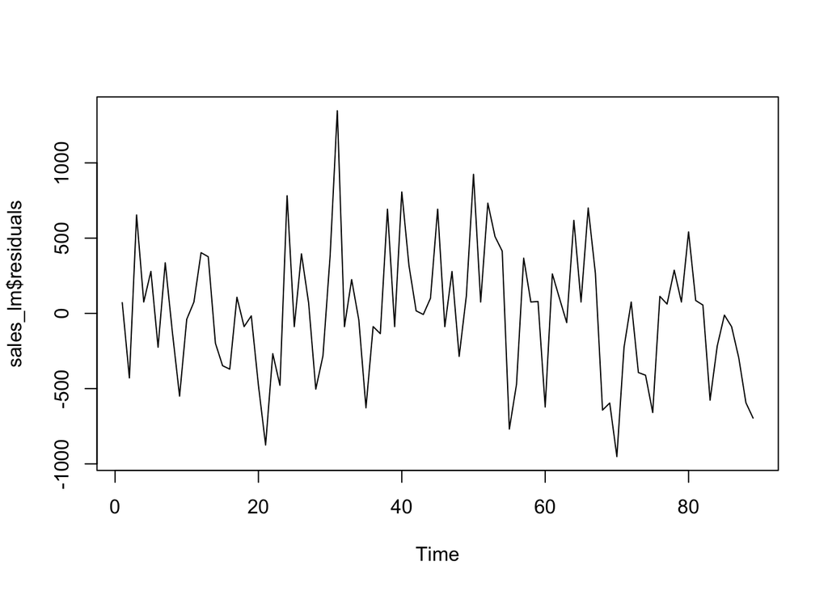

```r
# residual analysis
ts.plot(sales_lm$residuals)
```

```r
dwtest(sales_lm)
```

```
##
##  Durbin-Watson test
##
## data:  sales_lm
## DW = 1.5517, p-value = 0.01075
## alternative hypothesis: true autocorrelation is greater than 0
```

```r
# prediction
covariates <- c("Open", "Promo", "SchoolHoliday")
sales_lm_fcst <- predict(sales_lm, newdata=sales_test[, covariates])

# ARIMA로 모델링하여 예측수행 - 시계열분석
sales_train <- ts(sales_train, frequency=7) #요일 효과가 있다고 가정

# ARIMA 모델구현
sales_fit1 <- auto.arima(sales_train[, "Sales"])
sales_forecast1 <- forecast(sales_fit1, h=7)

# 1-MAPE
mean(100 - 100*abs(as.numeric(sales_forecast1$mean[-4]) - as.numeric(sales_test$Sales[-4])) / as.numeric(sales_test$Sales[-4]))
```

```
## [1] 91.38862
```

## Regression with ARIMA errors

1. 회귀모형으로 x변수들을 설명하고, 나머지 잔차를 ARIMA모형으로 설명.
2. auto.arima함수를 사용하는데, auto.airma(data, xreg) xreg 옵션에 x변수를 넣어준다.
3. 회귀가 들어간 ARIMA모형이기 떄문에 forecast를 할 떄도 xreg를 넣어줘야 한다.

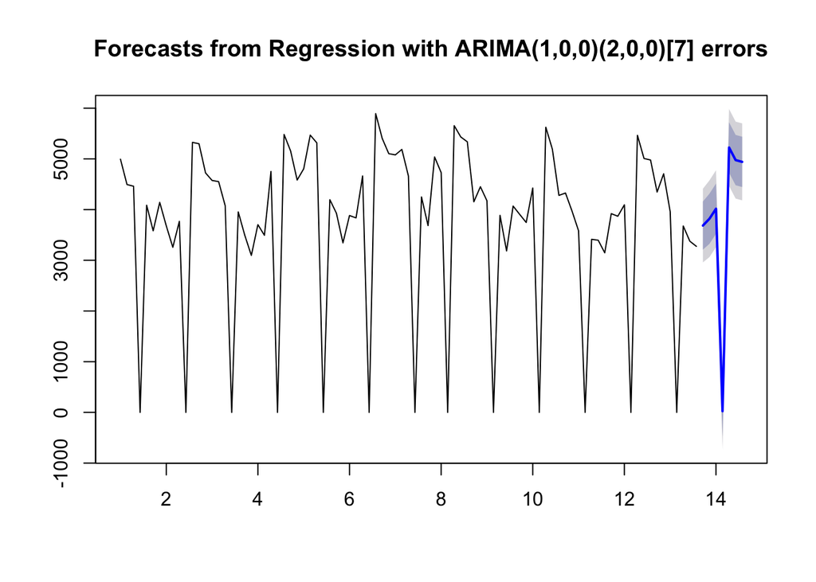

```r
# Regression With ARIMA errors
# ARIMA + Regression
covariates <- c("Open", "Promo", "SchoolHoliday")
sales_fit2 <- auto.arima(sales_train[,"Sales"], xreg=sales_train[,covariates])

# forecasting
sales_fcst <- forecast(sales_fit2, xreg=ts(sales_test[, covariates])) # test 데이터 역시 ts형태로 만들어줘야 한다. auto.arima를 쓸 경우.
plot(sales_fcst)
```

```r
mean(100 - 100*abs(as.numeric(sales_fcst$mean[-4]) - as.numeric(sales_test$Sales[-4])) / as.numeric(sales_test$Sales[-4]))
```

```
## [1] 90.59879
```